# Credit Card Fraud Detection

## Credit Card Fraud Detection

## Author: Samikshya Sapkota

[figure not shown]

```python
from PIL import Image #To read the image
Image.open("CC Fraud.png")
```

### Overview

Credit card fraud detection has become one of the most important aspects in this era of digital payment as we move towards a cashless society. Fraudsters have developed new and ingenious tactics to gain access to credit cardholders' financial information over time.Therefore, online consumers have been facing various credit card fraudulent activities since the introduction of credit card transactions. It is important that credit card companies are able to recognize fraudulent credit card transactions so that customers are not charged for items that they did not purchase.

As an undergraduate who has profound interest in Cybersecurity, I am an enthusiast to work on the ongoing issue (i.e credit card fraud) in cyber market, hence I decided to build a credit card fraud detection algorithm.

Stay tuned !!

### The Dataset

The following dataset has been collected and analysed during a research collaboration of Worldline and the Machine Learning Group of ULB (Université Libre de Bruxelles) on big data mining and fraud detection. The credit card transaction dataset that is being used contains Anonymized credit card transactions labeled as Fradulent(1) or Genuine(0) made by credit cards in September 2013 by European cardholders.

We obtained this dataset from https://www.kaggle.com/datasets/mlg-ulb/creditcardfraud

### Reading the data and importing the necessary libraries as required

```python
import numpy as np
import pandas as pd
import matplotlib.pyplot as plt
import seaborn as sns
from sklearn.preprocessing import StandardScaler


from sklearn.model_selection import train_test_split

from sklearn.linear_model import LogisticRegression
from sklearn.neighbors import KNeighborsClassifier
from sklearn.tree import DecisionTreeClassifier
from sklearn.ensemble import RandomForestClassifier
from sklearn.model_selection import cross_val_score


from sklearn.metrics import roc_auc_score
from sklearn.model_selection import cross_val_predict


from sklearn.metrics import confusion_matrix
from sklearn.metrics import accuracy_score
from sklearn.metrics import f1_score
from sklearn.metrics import classification_report
```

```python
read_data = pd.read_csv("creditcard.csv")
```

```python
read_data.head()
```

|  | Time | V1 | V2 | V3 | V4 | V5 | V6 | V7 | V8 | V9 | ... | V21 | V22 | V23 | V24 | V25 | V26 | V27 | V28 | Amount | Class |
| --- | --- | --- | --- | --- | --- | --- | --- | --- | --- | --- | --- | --- | --- | --- | --- | --- | --- | --- | --- | --- | --- |
| 0 | 0.0 | -1.359807 | -0.072781 | 2.536347 | 1.378155 | -0.338321 | 0.462388 | 0.239599 | 0.098698 | 0.363787 | ... | -0.018307 | 0.277838 | -0.110474 | 0.066928 | 0.128539 | -0.189115 | 0.133558 | -0.021053 | 149.62 | 0 |
| 1 | 0.0 | 1.191857 | 0.266151 | 0.166480 | 0.448154 | 0.060018 | -0.082361 | -0.078803 | 0.085102 | -0.255425 | ... | -0.225775 | -0.638672 | 0.101288 | -0.339846 | 0.167170 | 0.125895 | -0.008983 | 0.014724 | 2.69 | 0 |
| 2 | 1.0 | -1.358354 | -1.340163 | 1.773209 | 0.379780 | -0.503198 | 1.800499 | 0.791461 | 0.247676 | -1.514654 | ... | 0.247998 | 0.771679 | 0.909412 | -0.689281 | -0.327642 | -0.139097 | -0.055353 | -0.059752 | 378.66 | 0 |
| 3 | 1.0 | -0.966272 | -0.185226 | 1.792993 | -0.863291 | -0.010309 | 1.247203 | 0.237609 | 0.377436 | -1.387024 | ... | -0.108300 | 0.005274 | -0.190321 | -1.175575 | 0.647376 | -0.221929 | 0.062723 | 0.061458 | 123.50 | 0 |
| 4 | 2.0 | -1.158233 | 0.877737 | 1.548718 | 0.403034 | -0.407193 | 0.095921 | 0.592941 | -0.270533 | 0.817739 | ... | -0.009431 | 0.798278 | -0.137458 | 0.141267 | -0.206010 | 0.502292 | 0.219422 | 0.215153 | 69.99 | 0 |

5 rows × 31 columns

```python
#Check for any null values in the entire dataset
read_data.isnull().values.any()


#There are no null values in the dataset, hence we do not have to worry about trimming the dataset
#in terms of null values.
```

```
False
```

```python
print(read_data)
```

```
            Time         V1         V2        V3        V4        V5  \
0            0.0  -1.359807  -0.072781  2.536347  1.378155 -0.338321
1            0.0   1.191857   0.266151  0.166480  0.448154  0.060018
2            1.0  -1.358354  -1.340163  1.773209  0.379780 -0.503198
3            1.0  -0.966272  -0.185226  1.792993 -0.863291 -0.010309
4            2.0  -1.158233   0.877737  1.548718  0.403034 -0.407193
...          ...        ...        ...       ...       ...       ...
284802  172786.0 -11.881118  10.071785 -9.834783 -2.066656 -5.364473
284803  172787.0  -0.732789  -0.055080  2.035030 -0.738589  0.868229
284804  172788.0   1.919565  -0.301254 -3.249640 -0.557828  2.630515
284805  172788.0  -0.240440   0.530483  0.702510  0.689799 -0.377961
284806  172792.0  -0.533413  -0.189733  0.703337 -0.506271 -0.012546

              V6        V7        V8        V9  ...       V21       V22  \
0       0.462388  0.239599  0.098698  0.363787  ... -0.018307  0.277838
```

[output cut: 38 more lines]

```python
count_fraud = len(read_data[read_data['Class'] == 1])
count_nonFraud = len(read_data[read_data['Class'] == 0])

print("Total number of Fradulent Transactions = " + str(count_fraud))
print("Total number of Non-Fradulent Transactions = " + str(count_nonFraud))

print("Percentage of Fradulent Transaction = " + str(count_fraud/len(read_data)*100))
print("Percentage of Non-Fradulent Transaction = " + str(count_nonFraud/len(read_data)*100))
```

```
Total number of Fradulent Transactions = 492
Total number of Non-Fradulent Transactions = 284315
Percentage of Fradulent Transaction = 0.1727485630620034
Percentage of Non-Fradulent Transaction = 99.82725143693798
```

### Points to be noted:

The dataset contains only numerical values which are the result of Principal Component Analysis(PCA) transformation as described in the website. The reason for performing a PCA transformation was that information about credit cards is confidential and therefore, the authors who created the dataset decided to transform the orginal features into PCA components such as V1, V2, V3 ... V28.

The percentage of Fradulent Transactions was just 0.17% which makes this dataset highly imbalance, and this is an important aspect we have to take into account when pre-processing the data

[figure not shown]

```python
#Heatmap showing how the features are correlated to each other
sns.heatmap(read_data.corr(), cmap="YlGnBu").set(title = "Heatmap for imbalanced dataset")
sns.set(rc={'figure.figsize':(13,13)})
```

## Data Pre-Processing and Exploratory Data Analysis

```python
#Renaming a few columuns for Simplicity.
read_data = read_data.rename(columns={'Class': 'Category(0 or 1)',})
read_data.describe()
```

|  | Time | V1 | V2 | V3 | V4 | V5 | V6 | V7 | V8 | V9 | ... | V21 | V22 | V23 | V24 | V25 | V26 | V27 | V28 | Amount | Category(0 or 1) |
| --- | --- | --- | --- | --- | --- | --- | --- | --- | --- | --- | --- | --- | --- | --- | --- | --- | --- | --- | --- | --- | --- |
| count | 284807.000000 | 2.848070e+05 | 2.848070e+05 | 2.848070e+05 | 2.848070e+05 | 2.848070e+05 | 2.848070e+05 | 2.848070e+05 | 2.848070e+05 | 2.848070e+05 | ... | 2.848070e+05 | 2.848070e+05 | 2.848070e+05 | 2.848070e+05 | 2.848070e+05 | 2.848070e+05 | 2.848070e+05 | 2.848070e+05 | 284807.000000 | 284807.000000 |
| mean | 94813.859575 | 3.918649e-15 | 5.682686e-16 | -8.761736e-15 | 2.811118e-15 | -1.552103e-15 | 2.040130e-15 | -1.698953e-15 | -1.893285e-16 | -3.147640e-15 | ... | 1.473120e-16 | 8.042109e-16 | 5.282512e-16 | 4.456271e-15 | 1.426896e-15 | 1.701640e-15 | -3.662252e-16 | -1.217809e-16 | 88.349619 | 0.001727 |
| std | 47488.145955 | 1.958696e+00 | 1.651309e+00 | 1.516255e+00 | 1.415869e+00 | 1.380247e+00 | 1.332271e+00 | 1.237094e+00 | 1.194353e+00 | 1.098632e+00 | ... | 7.345240e-01 | 7.257016e-01 | 6.244603e-01 | 6.056471e-01 | 5.212781e-01 | 4.822270e-01 | 4.036325e-01 | 3.300833e-01 | 250.120109 | 0.041527 |
| min | 0.000000 | -5.640751e+01 | -7.271573e+01 | -4.832559e+01 | -5.683171e+00 | -1.137433e+02 | -2.616051e+01 | -4.355724e+01 | -7.321672e+01 | -1.343407e+01 | ... | -3.483038e+01 | -1.093314e+01 | -4.480774e+01 | -2.836627e+00 | -1.029540e+01 | -2.604551e+00 | -2.256568e+01 | -1.543008e+01 | 0.000000 | 0.000000 |
| 25% | 54201.500000 | -9.203734e-01 | -5.985499e-01 | -8.903648e-01 | -8.486401e-01 | -6.915971e-01 | -7.682956e-01 | -5.540759e-01 | -2.086297e-01 | -6.430976e-01 | ... | -2.283949e-01 | -5.423504e-01 | -1.618463e-01 | -3.545861e-01 | -3.171451e-01 | -3.269839e-01 | -7.083953e-02 | -5.295979e-02 | 5.600000 | 0.000000 |
| 50% | 84692.000000 | 1.810880e-02 | 6.548556e-02 | 1.798463e-01 | -1.984653e-02 | -5.433583e-02 | -2.741871e-01 | 4.010308e-02 | 2.235804e-02 | -5.142873e-02 | ... | -2.945017e-02 | 6.781943e-03 | -1.119293e-02 | 4.097606e-02 | 1.659350e-02 | -5.213911e-02 | 1.342146e-03 | 1.124383e-02 | 22.000000 | 0.000000 |
| 75% | 139320.500000 | 1.315642e+00 | 8.037239e-01 | 1.027196e+00 | 7.433413e-01 | 6.119264e-01 | 3.985649e-01 | 5.704361e-01 | 3.273459e-01 | 5.971390e-01 | ... | 1.863772e-01 | 5.285536e-01 | 1.476421e-01 | 4.395266e-01 | 3.507156e-01 | 2.409522e-01 | 9.104512e-02 | 7.827995e-02 | 77.165000 | 0.000000 |
| max | 172792.000000 | 2.454930e+00 | 2.205773e+01 | 9.382558e+00 | 1.687534e+01 | 3.480167e+01 | 7.330163e+01 | 1.205895e+02 | 2.000721e+01 | 1.559499e+01 | ... | 2.720284e+01 | 1.050309e+01 | 2.252841e+01 | 4.584549e+00 | 7.519589e+00 | 3.517346e+00 | 3.161220e+01 | 3.384781e+01 | 25691.160000 | 1.000000 |

8 rows × 31 columns

#### It can be observed that these features have some impact on the Category in the following ways:

- Features like V2, V4, V8, V11 are blue-ish conveying that these are positively correlated to category
- Features like V3, V7, V10, V12, V14, V16,V17 are yellow-ish conveying that these are negatively coorelated to category.
- The rest of the features have no impact on the category, i.e that they are deemed to be neutral.

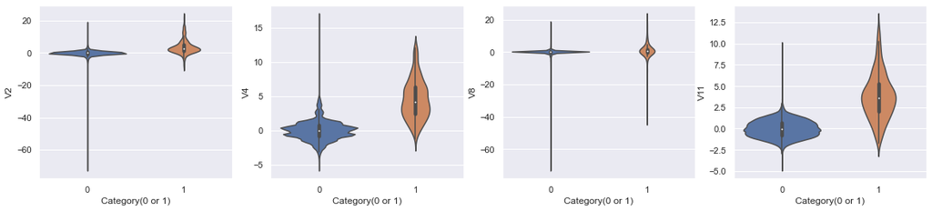

```python
#Violin plots
f, axes = plt.subplots(ncols=4, figsize=(20,4))
sns.violinplot(x="Category(0 or 1)", y="V2", data=read_data, ax = axes[0])
sns.violinplot(x="Category(0 or 1)", y="V4", data=read_data, ax = axes[1])
sns.violinplot(x="Category(0 or 1)", y="V8", data=read_data, ax = axes[2])
sns.violinplot(x="Category(0 or 1)", y="V11", data=read_data, ax = axes[3])
```

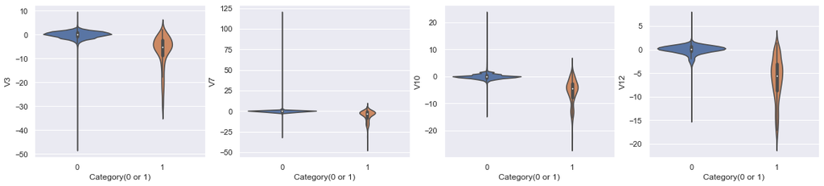

```python
f, axes = plt.subplots(ncols=4, figsize=(20,4))
sns.violinplot(x="Category(0 or 1)", y="V3", data=read_data, ax = axes[0])
sns.violinplot(x="Category(0 or 1)", y="V7", data=read_data, ax = axes[1])
sns.violinplot(x="Category(0 or 1)", y="V10", data=read_data, ax = axes[2])
sns.violinplot(x="Category(0 or 1)", y="V12", data=read_data, ax = axes[3])
```

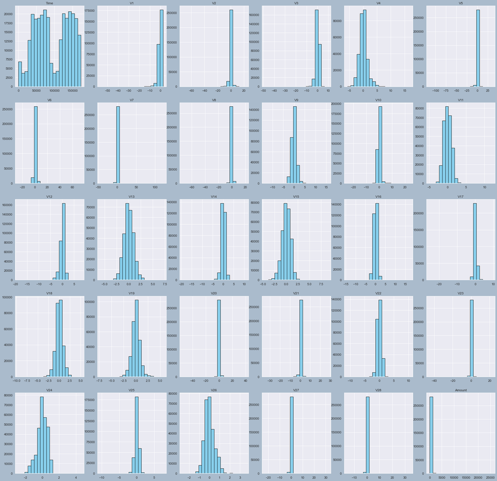

```python
#Bar Plots for V1, V2.....V29

fig = plt.figure(figsize=(30,30))
grid = fig.add_gridspec(5,6)

subplot_list = []
for x in range(0,5):
    for y in range(0,6):
        subplot_list.append(fig.add_subplot(grid[x,y]))


fig.patch.set_facecolor("#aabbcc")
cols = read_data.columns



for col, subplot in zip(cols, subplot_list):
    subplot.hist(read_data[col], bins = 20, ec="black", color = "skyblue")
    subplot.set_title(col)

plt.show()
```

#### Observations:

[output not shown]

[figure not shown]

```python
sns.distplot(read_data['Amount'], bins = 20,  color = "skyblue")

read_data.describe()['Amount']
```

[output not shown]

[figure not shown]

```python
sns.distplot(read_data['Time'], bins = 20,  color = "skyblue")
read_data.describe()['Time']
```

```python
scaler = StandardScaler()
amount = read_data['Amount'].values
read_data['Amount'] = scaler.fit_transform(amount.reshape(-1, 1))
time = read_data['Time'].values
read_data['Time'] = scaler.fit_transform(amount.reshape(-1, 1))
```

```python
read_data.describe()['Amount']
```

```
count    2.848070e+05
mean     3.202236e-16
std      1.000002e+00
min     -3.532294e-01
25%     -3.308401e-01
50%     -2.652715e-01
75%     -4.471707e-02
max      1.023622e+02
Name: Amount, dtype: float64
```

```python
read_data.describe()['Time']
```

```
count    2.848070e+05
mean     2.727008e-16
std      1.000002e+00
min     -3.532294e-01
25%     -3.308401e-01
50%     -2.652715e-01
75%     -4.471707e-02
max      1.023622e+02
Name: Time, dtype: float64
```

### Observation:

```python
read_data.head()
```

|  | Time | V1 | V2 | V3 | V4 | V5 | V6 | V7 | V8 | V9 | ... | V21 | V22 | V23 | V24 | V25 | V26 | V27 | V28 | Amount | Category(0 or 1) |
| --- | --- | --- | --- | --- | --- | --- | --- | --- | --- | --- | --- | --- | --- | --- | --- | --- | --- | --- | --- | --- | --- |
| 0 | 0.244964 | -1.359807 | -0.072781 | 2.536347 | 1.378155 | -0.338321 | 0.462388 | 0.239599 | 0.098698 | 0.363787 | ... | -0.018307 | 0.277838 | -0.110474 | 0.066928 | 0.128539 | -0.189115 | 0.133558 | -0.021053 | 0.244964 | 0 |
| 1 | -0.342475 | 1.191857 | 0.266151 | 0.166480 | 0.448154 | 0.060018 | -0.082361 | -0.078803 | 0.085102 | -0.255425 | ... | -0.225775 | -0.638672 | 0.101288 | -0.339846 | 0.167170 | 0.125895 | -0.008983 | 0.014724 | -0.342475 | 0 |
| 2 | 1.160686 | -1.358354 | -1.340163 | 1.773209 | 0.379780 | -0.503198 | 1.800499 | 0.791461 | 0.247676 | -1.514654 | ... | 0.247998 | 0.771679 | 0.909412 | -0.689281 | -0.327642 | -0.139097 | -0.055353 | -0.059752 | 1.160686 | 0 |
| 3 | 0.140534 | -0.966272 | -0.185226 | 1.792993 | -0.863291 | -0.010309 | 1.247203 | 0.237609 | 0.377436 | -1.387024 | ... | -0.108300 | 0.005274 | -0.190321 | -1.175575 | 0.647376 | -0.221929 | 0.062723 | 0.061458 | 0.140534 | 0 |
| 4 | -0.073403 | -1.158233 | 0.877737 | 1.548718 | 0.403034 | -0.407193 | 0.095921 | 0.592941 | -0.270533 | 0.817739 | ... | -0.009431 | 0.798278 | -0.137458 | 0.141267 | -0.206010 | 0.502292 | 0.219422 | 0.215153 | -0.073403 | 0 |

5 rows × 31 columns

### Dealing with Imbalance

- Why bother dealing with imbalance? An important thing to understand is that our fradulent transactions are a very small fraction of the entire data, hence when we train our models, there is a strong possibility that it can lead to overfitting. After scanning through this article (https://www.analyticsvidhya.com/blog/2020/07/10-techniques-to-deal-with-class-imbalance-in-machine-learning) , here is how I decided to tackle the issue of imbalance:
- Random Under-Sampling: it is defined as removing some observations of the majority class(here, Non-Fradulent).In short, we will take equal number of rows for both the categories.
- From the initial calculations, the number of fradulent transaction were 492, so we can go ahead and randomly select 492 Non-Fradulent transaction rows.
- Now, we have equally balanced dataset of 492 rows of both Fradulent and Non-Fradulent transactions

```python
copy_data = read_data.copy()
copy_data = copy_data.sample(frac = 1)

equal_df = pd.concat([copy_data.loc[copy_data['Category(0 or 1)'] == 1],
                                   copy_data.loc[copy_data['Category(0 or 1)'] == 0][:492]])

equal_df = equal_df.sample(frac=1, random_state=42)
```

```python
equal_df
```

|  | Time | V1 | V2 | V3 | V4 | V5 | V6 | V7 | V8 | V9 | ... | V21 | V22 | V23 | V24 | V25 | V26 | V27 | V28 | Amount | Category(0 or 1) |
| --- | --- | --- | --- | --- | --- | --- | --- | --- | --- | --- | --- | --- | --- | --- | --- | --- | --- | --- | --- | --- | --- |
| 211412 | -0.313289 | -0.966969 | 0.409230 | 1.311715 | 0.755450 | 0.706812 | 0.846389 | -0.197567 | 0.261176 | 0.083671 | ... | 0.379147 | 1.169031 | -0.355595 | 0.248513 | -0.143178 | -0.369764 | -0.212065 | 0.323346 | -0.313289 | 0 |
| 191359 | -0.333759 | 1.177824 | 2.487103 | -5.330608 | 5.324547 | 1.150243 | -1.281843 | -1.171994 | 0.413778 | -2.659840 | ... | 0.262325 | -0.431790 | -0.092088 | 0.145216 | 0.457788 | 0.167739 | 0.451243 | 0.268421 | -0.333759 | 1 |
| 19200 | -0.331640 | 1.511676 | -1.072169 | 0.822021 | -1.318579 | -1.859308 | -0.813361 | -1.280704 | -0.123510 | -1.554187 | ... | -0.067822 | 0.222190 | 0.009209 | 0.382484 | 0.333972 | -0.102117 | 0.051403 | 0.025599 | -0.331640 | 0 |
| 182992 | -0.340356 | 1.889618 | 1.073099 | -1.678018 | 4.173268 | 1.015516 | -0.009389 | -0.079706 | 0.064071 | -0.714517 | ... | 0.203728 | 0.733796 | -0.036560 | 0.334306 | 0.147171 | 0.279556 | 0.031669 | 0.035883 | -0.340356 | 1 |
| 42674 | -0.347152 | -7.896886 | 5.381020 | -8.451162 | 7.963928 | -7.862419 | -2.376820 | -11.949723 | 5.051356 | -6.912076 | ... | 2.557944 | 0.926278 | 0.032795 | 0.638073 | 0.361887 | 0.444577 | 1.101923 | 0.205958 | -0.347152 | 1 |
| ... | ... | ... | ... | ... | ... | ... | ... | ... | ... | ... | ... | ... | ... | ... | ... | ... | ... | ... | ... | ... | ... |
| 191544 | -0.029784 | 0.054682 | 1.856500 | -4.075451 | 4.100098 | -0.800931 | -0.292502 | -2.317431 | 1.189747 | -0.786238 | ... | 0.618248 | 0.800932 | 0.130016 | 0.288946 | -0.366658 | 0.030307 | 0.431182 | 0.110698 | -0.029784 | 1 |
| 102446 | -0.349231 | -13.192671 | 12.785971 | -9.906650 | 3.320337 | -4.801176 | 5.760059 | -18.750889 | -37.353443 | -0.391540 | ... | 27.202839 | -8.887017 | 5.303607 | -0.639435 | 0.263203 | -0.108877 | 1.269566 | 0.939407 | -0.349231 | 1 |
| 192200 | -0.213336 | 2.137179 | -0.855756 | -1.397431 | -0.684873 | -0.685919 | -0.568020 | -1.046669 | 0.040920 | 0.352452 | ... | 0.201754 | 0.512144 | 0.109818 | 0.323885 | -0.158969 | -0.100518 | 0.008437 | -0.008501 | -0.213336 | 0 |
| 8845 | -0.231728 | -4.727713 | 3.044469 | -5.598354 | 5.928191 | -2.190770 | -1.529323 | -4.487422 | 0.916392 | -1.307010 | ... | 0.650988 | 0.254983 | 0.628843 | -0.238128 | -0.671332 | -0.033590 | -1.331777 | 0.705698 | -0.231728 | 1 |
| 192382 | -0.345233 | 0.753356 | 2.284988 | -5.164492 | 3.831112 | -0.073622 | -1.316596 | -1.855495 | 0.831079 | -1.567514 | ... | 0.382007 | 0.033958 | 0.187697 | 0.358433 | -0.488934 | -0.258802 | 0.296145 | -0.047174 | -0.345233 | 1 |

984 rows × 31 columns

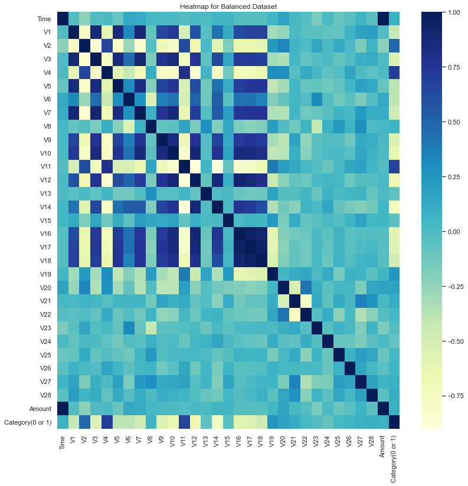

```python
#Heatmap showing how the features are correlated to each other
sns.heatmap(equal_df.corr(), cmap="YlGnBu").set( title = 'Heatmap for Balanced Dataset')
sns.set(rc={'figure.figsize':(13,13)})
```

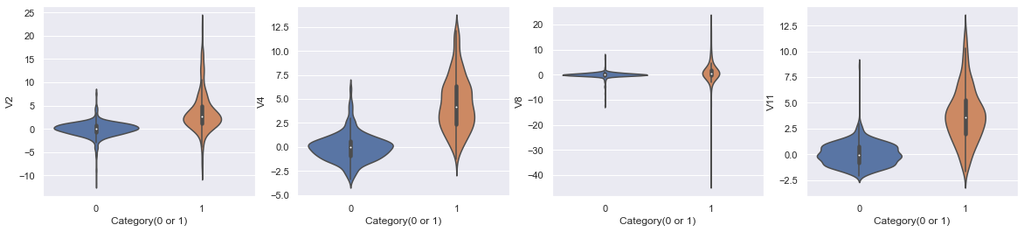

```python
#Positively Correlated features
f, axes = plt.subplots(ncols=4, figsize=(20,4))
sns.violinplot(x="Category(0 or 1)", y="V2", data=equal_df, ax = axes[0])
sns.violinplot(x="Category(0 or 1)", y="V4", data=equal_df, ax = axes[1])
sns.violinplot(x="Category(0 or 1)", y="V8", data=equal_df, ax = axes[2])
sns.violinplot(x="Category(0 or 1)", y="V11", data=equal_df, ax = axes[3])
```

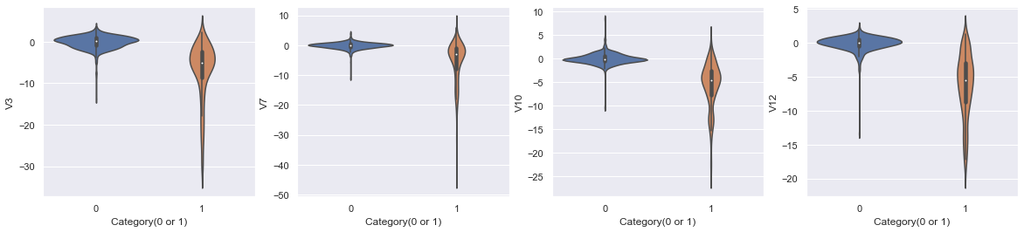

```python
#Negatively Correlated features
f, axes = plt.subplots(ncols=4, figsize=(20,4))
sns.violinplot(x="Category(0 or 1)", y="V3", data=equal_df, ax = axes[0])
sns.violinplot(x="Category(0 or 1)", y="V7", data=equal_df, ax = axes[1])
sns.violinplot(x="Category(0 or 1)", y="V10", data=equal_df, ax = axes[2])
sns.violinplot(x="Category(0 or 1)", y="V12", data=equal_df, ax = axes[3])
```

### Boxplots for positively correlated features: V2, V4, V8, V11

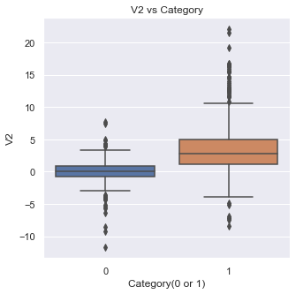

```python
sns.boxplot(x="Category(0 or 1)", y="V2", data=equal_df).set(title = "V2 vs Category")
sns.set(rc={'figure.figsize':(5,5)})
```

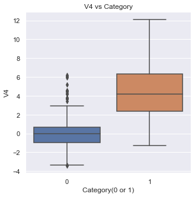

```python
sns.boxplot(x="Category(0 or 1)", y="V4", data=equal_df).set(title = "V4 vs Category")
sns.set(rc={'figure.figsize':(5,5)})
```

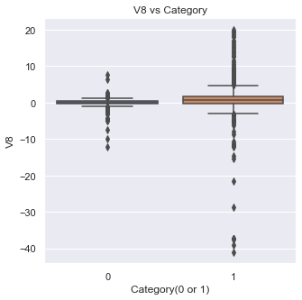

```python
sns.boxplot(x="Category(0 or 1)", y="V8", data=equal_df).set(title = "V8 vs Category")
sns.set(rc={'figure.figsize':(5,5)})
```

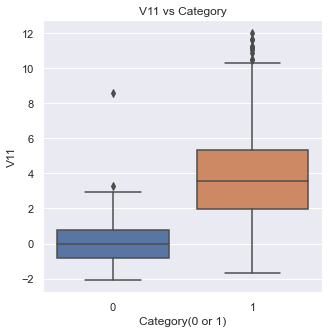

```python
sns.boxplot(x="Category(0 or 1)", y="V11", data=equal_df).set(title = "V11 vs Category")
sns.set(rc={'figure.figsize':(5,5)})
```

### Boxplots for negatively correlated features: V3, V7, V10, V12

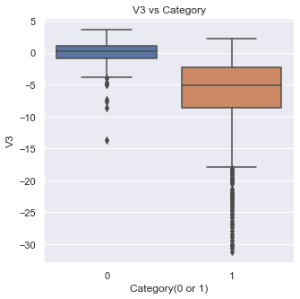

```python
sns.boxplot(x="Category(0 or 1)", y="V3", data=equal_df).set(title = "V3 vs Category")
sns.set(rc={'figure.figsize':(5,5)})
```

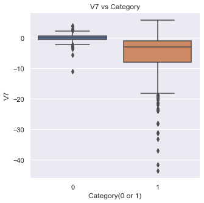

```python
sns.boxplot(x="Category(0 or 1)", y="V7", data=equal_df).set(title = "V7 vs Category")
sns.set(rc={'figure.figsize':(5,5)})
```

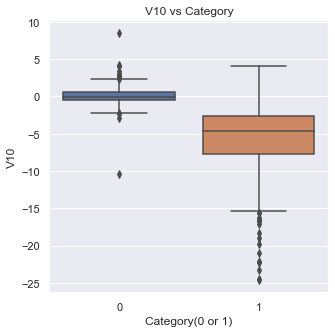

```python
sns.boxplot(x="Category(0 or 1)", y="V10", data=equal_df).set(title = "V10 vs Category")
sns.set(rc={'figure.figsize':(5,5)})
```

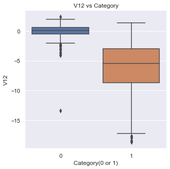

```python
sns.boxplot(x="Category(0 or 1)", y="V12", data=equal_df).set(title = "V12 vs Category")
sns.set(rc={'figure.figsize':(5,5)})
```

## Hypothesis Testing

### Balanced Data

```python
# Separating independent variables and the dependent variable
X = equal_df.drop('Category(0 or 1)', axis = 1)
Y = equal_df['Category(0 or 1)']
```

### Train + Test

```python
#Using the sklearn train_test_split, we will split the entire
#X and Y dataframe such that training set accounts for 80% of total

X_train, X_test, Y_train, Y_test = train_test_split(X, Y, train_size  = 0.8, random_state = 42)
```

### Defining three classifiers: Logistic Regression, k-Nearest , and Decision Tree

```python
models = {"Logistic Regression Classifier":LogisticRegression(), "k-Nearest Classifier": KNeighborsClassifier(),
          "Decision Tree Classifier": DecisionTreeClassifier()}
```

```python
#An important thing to note is that all these models take "array-like" inputs so we have to transform our
#train and test split
X_train = X_train.values
X_test = X_test.values
Y_train = Y_train.values
Y_test  = Y_test.values
```

### Cross Validation and Hyperparameter Tuning

- We will train our model using a method knows as k-fold Cross Validation. Cross Validation makes sure that the model picks up general patterns of data and does not end selecting noise or irrelevant patterns from the data. In this method, the dataset is partitioned into k-folds, where we specify 'k'. The first 'k-1' folds are used in training the data and the kth fold is used in testing data. Learn more about Cross Validation here(https://towardsdatascience.com/cross-validation-in-machine-learning-72924a69872f)
- Hyperparameter tuning is choosing a set of optimal hyperparameters for a learning algorithm. It served as a model argument whose values are set before we begin our model training. Hyperparameter is a vital step in machine learning algorithms.
- In short, hyper-parameter tuning is just an additional optimization step on top of the Machine Learning model the find the best set of hyper-parameters that could lead us the best prediction rates and lowest error. There are numerous Hyperparameter tuning method such as Random Search, Grid Search, Bayesian Optimization. etc but we will use Grid Search CV method.
- Grid Search: It is deemed as the simplest yet powerful method for hyperparameter tuning. The way it works is it divides the set of input hyperparameters into a grid. Then, every combination of values of this grid is tried, calculating some performance metrics using cross-validation. The point of the grid that maximizes the average value in cross-validation, is the optimal combination of values for the hyperparameters (Source: https://www.yourdatateacher.com/2021/05/19/hyperparameter-tuning-grid-search-and-random-search/#:~:text=Grid%20search%20is%20the%20simplest,performance%20metrics%20using%20cross%2Dvalidation.)

To understand more about Grid Search CV and how it works with each classifier, these links were quite helpful for me:

1. https://www.kaggle.com/code/enespolat/grid-search-with-logistic-regression/notebook
2. https://towardsdatascience.com/tuning-the-hyperparameters-of-your-machine-learning-model-using-gridsearchcv-7fc2bb76ff27
3. https://machinelearningmastery.com/hyperparameter-optimization-with-random-search-and-grid-search/

```python
#Usually, the first or rather the easiest step is to perform cross validation and check the prediction score for
#each type of classifier. We do not have idea of what are the best parameters to tweak at this point so initially
#we just start by choosing default parameters

for k, v in models.items():
    v.fit(X_train, Y_train)
    score = cross_val_score(v, X_train, Y_train)
    print( "The training score for " + k +" = " + str(score.mean()*100) + "%")
```

```
The training score for Logistic Regression Classifier = 92.50181407723937%
The training score for k-Nearest Classifier = 92.75578489075225%
The training score for Decision Tree Classifier = 90.08949447714262%
```

### Grid Search CV for logistic regression

```python
from sklearn.model_selection import GridSearchCV
```

```python
LR_parameters={"C":np.logspace(-3,3,7), "penalty":["l1","l2"]}
grid_LR = GridSearchCV(LogisticRegression(), LR_parameters)

grid_LR.fit(X_train, Y_train)

best_LR_parameters  = grid_LR.best_estimator_
```

```python
grid_lr_score = cross_val_score(best_LR_parameters, X_train, Y_train)
print( "The training score for Logistic Regression using Grid Search CV = " + str(grid_lr_score.mean()*100) + "%")
```

```
The training score for Logistic Regression using Grid Search CV = 99.92056002984485%
```

```python
lr_predict_imbalance = cross_val_predict(grid_LR, X_test, Y_test)
print('The testing score for Logistic Regression using Grid Search CV = ' +
      str(roc_auc_score(Y_test, lr_predict_imbalance)*100)+"%")
```

```
The testing score for Logistic Regression using Grid Search CV = 79.07283974366337%
```

### Grid Search CV for k-Neighbors Classifier

```python
KN_parameters = {'n_neighbors':[3,5,11,19], 'weights':['uniform', 'distance'],
                'metric':['euclidean', 'manhattan']}

grid_KN = GridSearchCV(KNeighborsClassifier(), KN_parameters)

grid_KN.fit(X_train, Y_train)

best_KN_parameters  = grid_KN.best_estimator_
```

```python
grid_kn_score = cross_val_score(best_KN_parameters, X_train, Y_train)
print( "The training score for k-Neighbors Classifies using Grid Search CV = " +
      str(grid_kn_score.mean()*100) + "%")
```

```
The training score for k-Neighbors Classifies using Grid Search CV = 93.01217447391761%
```

```python
KN_predict_imbalance = cross_val_predict(grid_KN, X_test, Y_test)
print('The testing score for k-Neighbors Classifier using Grid Search CV = ' +
      str(roc_auc_score(Y_test, KN_predict_imbalance)*100)+"%")
```

```
The testing score for k-Neighbors Classifier using Grid Search CV = 95.45454545454545%
```

### Grid Search CV for Decision Tree Classifier

```python
DT_parameters = {'criterion':['gini','entropy'],
                  'max_depth':[4,5,6,7,8,9,10,11,12,15,20,30,40,50,70,90,120,150]}

grid_DT = GridSearchCV(DecisionTreeClassifier(), DT_parameters)
grid_DT.fit(X_train, Y_train)
best_DT_parameters  = grid_DT.best_estimator_
```

```python
grid_DT_score = cross_val_score(best_DT_parameters, X_train, Y_train)
print( "The training score for Decision Tree Classifier using Grid Search CV = " +
      str(grid_DT_score.mean()*100) + "%")
```

```
The training score for Decision Tree Classifier using Grid Search CV = 91.86970894138516%
```

```python
grid_predict_imbalance = cross_val_predict(grid_DT, X_test, Y_test)
print('The testing score for Decision Tree Classifier using Grid Search CV = ' +
      str(roc_auc_score(Y_test, grid_predict_imbalance)*100)+"%")
```

```
The testing score for Decision Tree Classifier using Grid Search CV = 87.28840125391851%
```